# Crispr/Cas9 gRNA design

Aditya M Bhagwat

1 11 2019

# Overview

Crispr/Cas9, first described in 1987, later understood to be a prokaryotic immune system, has now transformed into a powerful and versatile tool for genome engineering, with continuing active development. As a genome engineering tool, it consists of two parts: the **Cas9** enzyme that unwinds and cuts double stranded DNA, and a **gRNA** (guide RNA) that targets the Cas9 enzyme to a specific genomic locus based on complementarity to a 23-bp N20NGG sequence.

The task of designing a Crispr/Cas9 gRNA library to target a set of genomic loci consists of the following steps:

1. Define genomic targets
2. Extend or flank targets (e.g. extend to ensure 23-bp width, flank to target promotors/enhancers)
3. Find potential N20NGG Cas9 sites within target loci
4. Predict targeting efficiency and filter for expected efficiency.
5. Find offtarget (mis)matches and filter for offtarget-free Cas9
6. Return offtarget-free, expectedly efficient Crispr/Cas9 gRNA site/sequence library

# 1 Define targets

As a first step, genomic targets are defined as `GRanges` (R/BioC class to represent genomic ranges). Convenient functions are provided to make this step easy.

The functions `genes_to_granges` or `genefile_to_granges` convert geneids into a GRanges, using a TxDb gene models object. Most Cas9 applications are strand-agnostic, so by default complementary strands are included with `complement = TRUE`:

```r
# Convert gene ids into GRanges
entrezfile <- system.file('extdata/SRF.entrez', package = 'multicrispr')
txdb <- TxDb.Mmusculus.UCSC.mm10.knownGene::TxDb.Mmusculus.UCSC.mm10.knownGene
targets0 <- genefile_to_granges(entrezfile, txdb, complement = TRUE)
```

```
##      Convert 10 genes to 10 GRanges
##      20 ranges after adding inverse strands
```

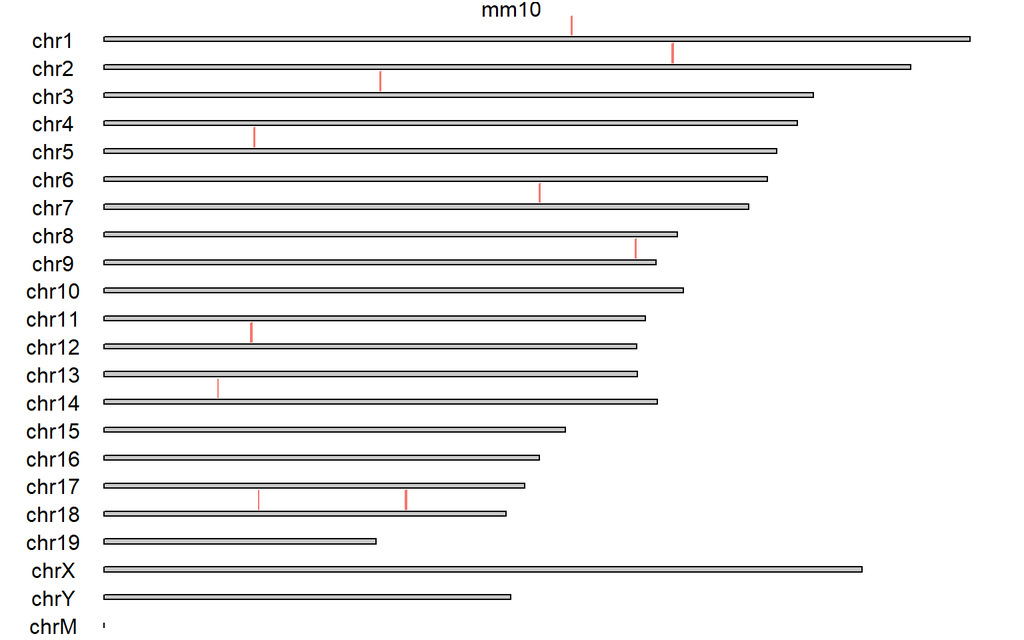

Alternatively, the function `bed_to_granges` directly reads a (0-based) BED file into a (1-based) GRanges object:

```r
# Read bedfile into GRanges
require(multicrispr)
bedfile <- system.file('extdata/SRF.bed', package = 'multicrispr')
targets0 <- bed_to_granges(bedfile, genome = 'mm10')
```

```
##  Read SRF.bed into GRanges
##      1974 ranges on 21 chromosomes
##      3948 ranges after adding inverse strands
```

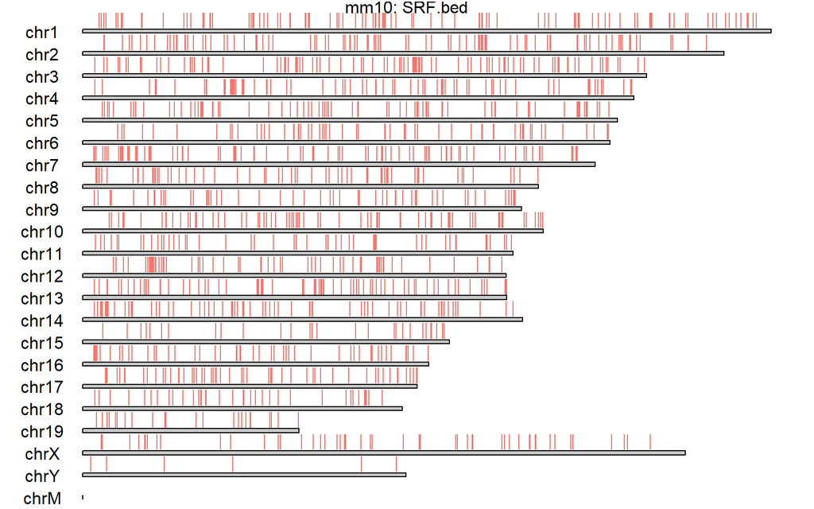

# 2 Extend/Flank targets

As a second step, extension or flanking may be required. The functions `left_flank`, `right_flank`, and `double_flank` flank target ranges, e.g. in order to target promoters or enhancers rather than TSS:

```r
# Left flank
targets <- left_flank(  targets0, leftstart =-200, leftend = -1)
```

```
##      3948 left  flanks: [start-200, start-1]
```

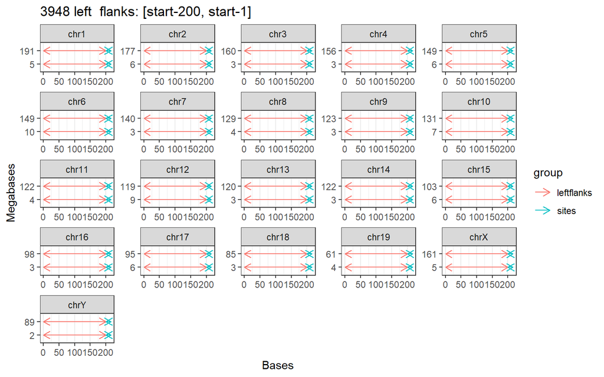

```r
# Right flank
targets <- right_flank( targets0, rightstart=   1, rightend=200)
```

```
##      3948 right flanks : [end+1, end+200]
```

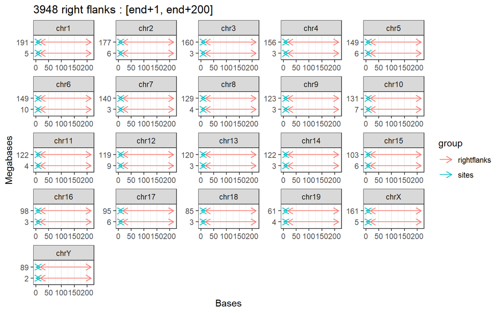

```r
# Double flank
targets <- double_flank(targets0, leftstart = -200, leftend=-1, rightstart=1, rightend=200)
```

```
##  Flank fourways
##      3948 left  flanks: [start-200, start-1]
##      3948 right flanks : [end+1, end+200]
##      7896 combined (left + right)
##      7306 after merging overlaps
```

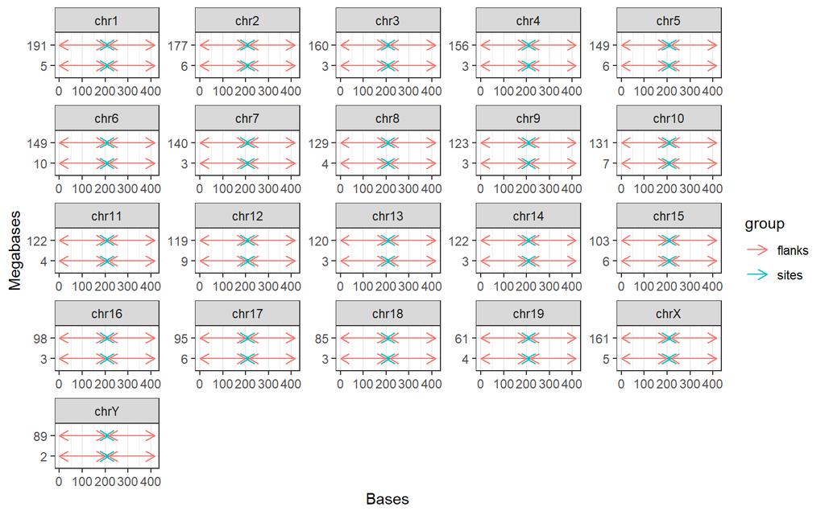

The function `extend` expands target ranges in either (or both) direction(s), ensuring proper width to contain 23 base Cas9 sites.

```r
targets <- extend(targets0, leftstart=-22, rightend=22)
```

```
##      3948 extended ranges: [start-22, end+22]
```

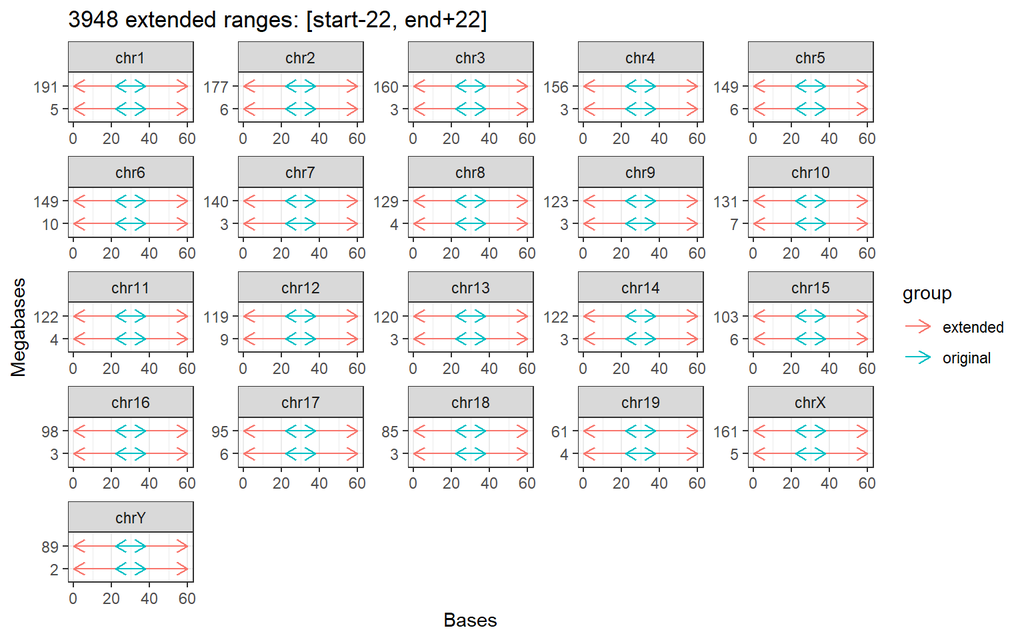

# 3 Find cas9 sites

The third step consists of finding N<sub>20</sub>NGG Cas9 sites within the target ranges.  
First, we use `add_seq` to extract the relevant sequences using a BSgenome (R/BioC genome sequence object).  
Then we use `find_cas9s` to find N<sub>20</sub>NGG Cas9 sequences and ranges within targets. The associated plot shows that (nearly) all targets have Cas9 sites.

```r
bsgenome <- BSgenome.Mmusculus.UCSC.mm10::BSgenome.Mmusculus.UCSC.mm10
targets <- add_seq(targets, bsgenome)
```

```
##  Add seq
```

```r
cas9s <- find_cas9s(targets)
```

[output not shown]

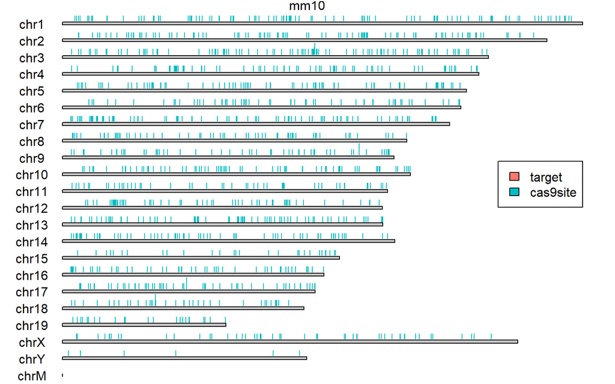

# 4 Predict targeting efficiency

Not all N<sub>20</sub>NGG gRNA sequences target equally well (even when matching sequence perfectly). For each position in the 23-bp gRNA sequence, the nucleotide present in current, previous and next position has an effect on targeting efficiency. Doench et al. (2014) were the first to systematically investigate the relationship between sequence and targeting efficiency, which they summarized in their 2014 prediction model. The function `score_cas9s` uses this model to compute the Doench 2014 targeting efficiency predictions:

```r
cas9s <- score_cas9s(cas9s, bsgenome, method = 'Doench2014')
```

```
##  Score cas9s
##      Add (4-23-3) contextseqs
##      Score contextseqs with Doench2014
```

```r
cas9s
## GRanges object with 4231 ranges and 3 metadata columns:
##          seqnames            ranges strand |                     contextseq
##             <Rle>         <IRanges>  <Rle> |                    <character>
##      [1]     chr1   4712631-4712653      - | ACACCTTCTGCTGGAGACAATATAAGGGCA
##      [2]     chr1   4712632-4712654      + | TGCCCTTATATTGTCTCCAGCAGAAGGTGT
##      [3]     chr1   5250215-5250237      - | ACACCTTCTGCTGGAGACAATATAAGGACA
##      [4]     chr1   5250216-5250238      + | TGTCCTTATATTGTCTCCAGCAGAAGGTGT
##      [5]     chr1   5250455-5250477      - | CCTGGTTGTCAACTTGACAATATTTGGAAT
##      ...      ...               ...    ... .                            ...
##   [4227]     chrY 42512390-42512412      + | ACAGAGCTCGCCATTCCACATATTTGGCCA
##   [4228]     chrY 79048179-79048201      - | ACACCTTCTGCTGGAGACAATATAAGGACA
##   [4229]     chrY 79048180-79048202      + | TGTCCTTATATTGTCTCCAGCAGAAGGTGT
##   [4230]     chrY 89126497-89126519      - | CCATTCCATATATTTGCCCATACTAGGGAG
##   [4231]     chrY 89126484-89126506      + | TTGTAAAAGCCGCTCTCCCTAGTATGGGCA
##                              seq         Doench2014
##                      <character>          <numeric>
##      [1] CTTCTGCTGGAGACAATATAAGG 0.0762913754743017
##      [2] CTTATATTGTCTCCAGCAGAAGG  0.175157065824598
##      [3] CTTCTGCTGGAGACAATATAAGG  0.141265329482966
##      [4] CTTATATTGTCTCCAGCAGAAGG 0.0872712653363744
##      [5] GTTGTCAACTTGACAATATTTGG 0.0936078028728409
##      ...                     ...                ...
##   [4227] AGCTCGCCATTCCACATATTTGG  0.036564870025776
##   [4228] CTTCTGCTGGAGACAATATAAGG  0.141265329482966
##   [4229] CTTATATTGTCTCCAGCAGAAGG 0.0872712653363744
##   [4230] TCCATATATTTGCCCATACTAGG 0.0238712426537427
##   [4231] AAAAGCCGCTCTCCCTAGTATGG  0.027168344708247
##   -------
##   seqinfo: 66 sequences (1 circular) from mm10 genome
```

The same authors later developed an updated model (Doench et al., 2016), which to-date remains the most comprehensive prediction model developed and the current community standard. The prediction model was implemented as a python module, which the authors freely share on github (github/MicrosoftResearch/azimuth). The installation of this python module is fairly straightforward:

Once azimuth is installed, `score_cas9s` can compute the Doench2016 score as well, under the hood calling the python module azimuth with a little help from the amazing R-to-python reticulate package.

```r
reticulate::use_condaenv('azi')
if (reticulate::py_module_available('azimuth')){
    cas9s <- score_cas9s(cas9s, bsgenome, method = 'Doench2016')
    cas9s
}
```

```
##  Score cas9s
##      Add (4-23-3) contextseqs
##      Score contextseqs with Doench2016 (https://github.com/MicrosoftResearch/Azimuth)
## No model file specified, using V3_model_nopos
## GRanges object with 4231 ranges and 4 metadata columns:
##          seqnames            ranges strand |                     contextseq
##             <Rle>         <IRanges>  <Rle> |                    <character>
##      [1]     chr1   4712631-4712653      - | ACACCTTCTGCTGGAGACAATATAAGGGCA
##      [2]     chr1   4712632-4712654      + | TGCCCTTATATTGTCTCCAGCAGAAGGTGT
##      [3]     chr1   5250215-5250237      - | ACACCTTCTGCTGGAGACAATATAAGGACA
##      [4]     chr1   5250216-5250238      + | TGTCCTTATATTGTCTCCAGCAGAAGGTGT
##      [5]     chr1   5250455-5250477      - | CCTGGTTGTCAACTTGACAATATTTGGAAT
##      ...      ...               ...    ... .                            ...
##   [4227]     chrY 42512390-42512412      + | ACAGAGCTCGCCATTCCACATATTTGGCCA
##   [4228]     chrY 79048179-79048201      - | ACACCTTCTGCTGGAGACAATATAAGGACA
##   [4229]     chrY 79048180-79048202      + | TGTCCTTATATTGTCTCCAGCAGAAGGTGT
##   [4230]     chrY 89126497-89126519      - | CCATTCCATATATTTGCCCATACTAGGGAG
##   [4231]     chrY 89126484-89126506      + | TTGTAAAAGCCGCTCTCCCTAGTATGGGCA
##                              seq         Doench2014        Doench2016
##                      <character>          <numeric>         <numeric>
##      [1] CTTCTGCTGGAGACAATATAAGG 0.0762913754743017 0.395297284364816
##      [2] CTTATATTGTCTCCAGCAGAAGG  0.175157065824598 0.618062383807203
##      [3] CTTCTGCTGGAGACAATATAAGG  0.141265329482966 0.458044323109665
##      [4] CTTATATTGTCTCCAGCAGAAGG 0.0872712653363744 0.613776236192383
##      [5] GTTGTCAACTTGACAATATTTGG 0.0936078028728409  0.19313390733822
##      ...                     ...                ...               ...
##   [4227] AGCTCGCCATTCCACATATTTGG  0.036564870025776 0.233900750484451
##   [4228] CTTCTGCTGGAGACAATATAAGG  0.141265329482966 0.458044323109665
##   [4229] CTTATATTGTCTCCAGCAGAAGG 0.0872712653363744 0.613776236192383
##   [4230] TCCATATATTTGCCCATACTAGG 0.0238712426537427 0.455569314805398
##   [4231] AAAAGCCGCTCTCCCTAGTATGG  0.027168344708247 0.341059813798791
##   -------
##   seqinfo: 66 sequences (1 circular) from mm10 genome
```

This allows us to discard Cas9 sites with a low expected targeting efficiency:

```r
cas9s <- cas9s[cas9s$Doench2016 > 0.5]
```

# 5 Prevent offtarget effects